# Image Classification

# How are Images Encoded?

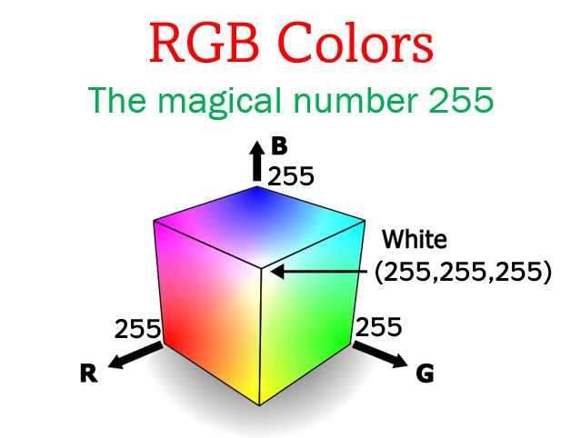

# Separating Color Channels

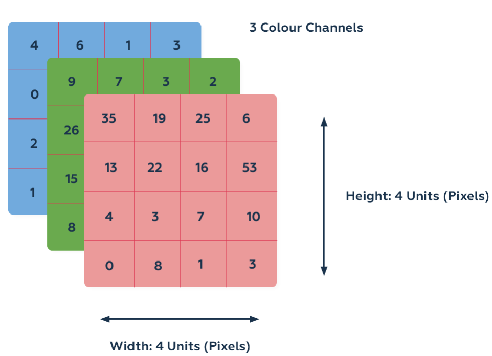

# Cat or Not Cat?

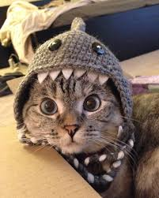

# Classical ML: The Average Cat

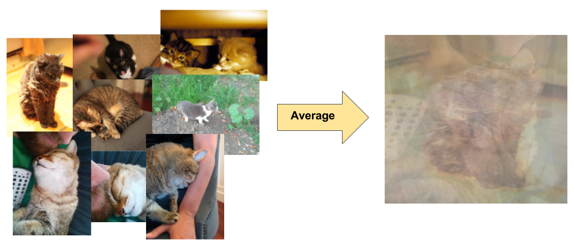

# Image Variablity is Hard

[figure not shown]

# Convolutional Neural Networks (CNNs)

- A CNN takes just the image's raw pixel data as input and "learns" how to extract these features
- To start, the CNN receives an input feature map: a three-dimensional matrix
  - The size of the first two dimensions correspond to the length and width of the image in pixels
  - The size of the third dimension is 3 (corresponding to the 3 channels of a color image: red, green, and blue)
- The input matrix doesn't always have to be three-dimensional! It will be equal to the number of channels in our input data
  - For example, grayscale images will by 1D since they only contain a single color of varying opacities

# Convolutional Filters

- Convolutional networks try and compress the relevant information in an image
- They do this initially by using **convolutional layers**
- A Convolutional layer is a sliding window that looks at a handful of pixels at a time and extracts something similar to an average pixel value
- The sliding window is called a **filter matrix**, and its weights are learned during model training
- Each step of the window performs the operation $\sum((A \odot B)_{ij})$ for each color channel, and sums the result across color channels

[figure not shown]

## I heard you like compression with your compression

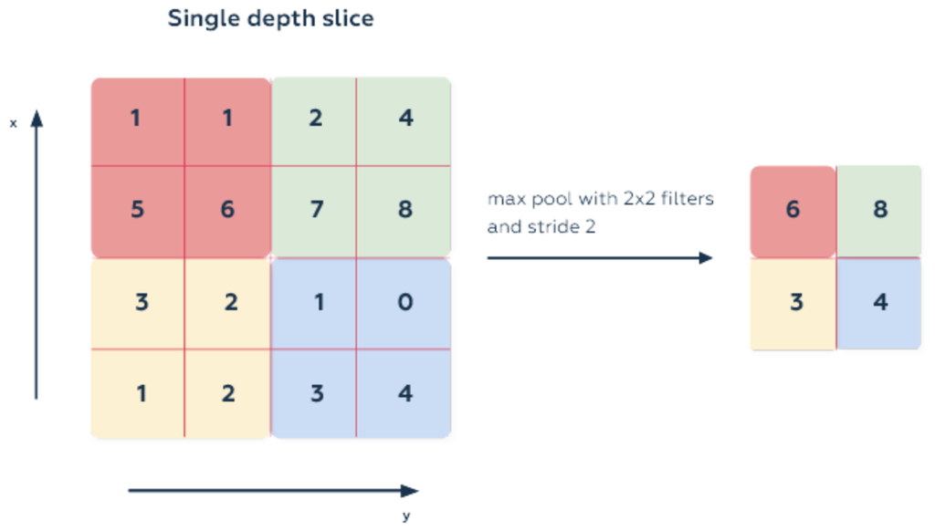

# Putting it Together

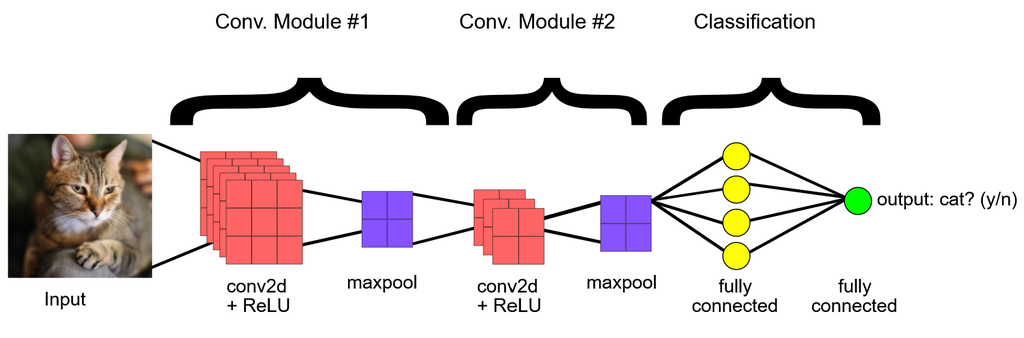